# Experiment Report

This report presents the analysis for **lr_xval_subgroups_with_int_ids_fold02**: Cross-validation with subgroups using a LinearRegression model. (Fold 02)

Mon Dec 5 10:17:58 2022

## Description of the data

### Responses excluded due to non-numeric feature values or scores

**Training set**

Total number of excluded responses: 0 (0.0% of the original 333)

**Evaluation set**

Total number of excluded responses: 0 (0.0% of the original 167)

The rest of this report is based only on the responses that were not excluded above.

Composition of the training and evaluation sets

| partition | responses | QUESTION | L1 |
| --- | --- | --- | --- |
| Training | 333 | 5 | 4 |
| Evaluation | 167 | 5 | 4 |
| Overlapping | 0 | 5 | 4 |
| Total | 500 | 5 | 4 |

Number of responses by QUESTION

| QUESTION | Training set | Evaluation set |
| --- | --- | --- |
| QUESTION_1 | 66 | 34 |
| QUESTION_2 | 70 | 30 |
| QUESTION_3 | 62 | 38 |
| QUESTION_4 | 64 | 36 |
| QUESTION_5 | 71 | 29 |

Number of responses by L1

| L1 | Training set | Evaluation set |
| --- | --- | --- |
| Esperanto | 79 | 48 |
| Klingon | 100 | 34 |
| Navi | 70 | 42 |
| Vulcan | 84 | 43 |

## Overall descriptive feature statistics

These values are reported before transformations.

[output not shown]

### Prevalence of recoded cases

This sections shows the number and percentage of cases truncated to mean +/- 4 SD for each feature.

[figure not shown]

### Feature value distribution

The following table shows additional statistics for the data. Quantiles are computed using type=3 method used in SAS. The mild outliers are defined as data points between [1.5, 3) * IQR away from the nearest quartile. Extreme outliers are the data points >= 3 * IQR away from the nearest quartile.

|  | 1% | 5% | 25% | 50% | 75% | 95% | 99% | IQR | Mild outliers | Extreme outliers |
| --- | --- | --- | --- | --- | --- | --- | --- | --- | --- | --- |
| FEATURE1 | 3.210 | 4.389 | 4.920 | 5.218 | 5.468 | 6.045 | 6.427 | 0.548 | 14 | 5 |
| FEATURE2 | -0.245 | -0.143 | -0.115 | -0.095 | -0.078 | -0.061 | -0.058 | 0.037 | 1 | 4 |
| FEATURE3 | -0.410 | -0.316 | -0.232 | -0.191 | -0.123 | -0.070 | -0.060 | 0.109 | 6 | 0 |
| FEATURE4 | -0.625 | -0.462 | -0.305 | -0.200 | -0.002 | 0.001 | 0.001 | 0.304 | 0 | 0 |
| FEATURE5 | -0.190 | -0.163 | -0.127 | -0.096 | -0.075 | -0.002 | 0.001 | 0.053 | 0 | 0 |
| FEATURE6 | 3.288 | 3.894 | 4.302 | 4.492 | 4.631 | 4.954 | 5.040 | 0.329 | 5 | 4 |
| FEATURE7 | 1.000 | 2.000 | 6.000 | 10.000 | 15.000 | 19.000 | 20.000 | 9.000 | 0 | 0 |
| FEATURE8 | -13421.860 | -12464.724 | -10302.544 | -8371.165 | -6306.962 | -4463.336 | -3711.225 | 3995.582 | 0 | 0 |

Feature values by QUESTION

In all plots in this subsection the values are reported before transformations/truncation. The lines indicate the threshold for truncation (mean +/- 4*SD).

[figure not shown]

Feature values by L1

In all plots in this subsection the values are reported before transformations/truncation. The lines indicate the threshold for truncation (mean +/- 4*SD).

[figure not shown]

## Feature distributions and inter-feature correlations

### Training set distributions

The following plot shows the distributions of the feature values in the training set, after transformation (if applicable), truncation and standardization (if applicable). The line shows the kernel density estimate. The human score (`sc1`) is also included.

Response length (`length`) is included if you specified `length_column` in the config file, unless the column had missing values or a standard deviation <= 0.

[figure not shown]

### Inter-feature correlations

The following table shows the Pearson correlations between all the training features after transformation (if applicable), truncation and standardization (if applicable). The human score (`sc1`) is also included.

Response length (`length`) is included if you specified `length_column` in the config file, unless the column had missing values or a standard deviation <= 0.

The following values are highlighted:

- inter-feature correlations above 0.7, and
- `sc1`-feature correlations lower than 0.1 or higher than 0.7

|  | sc1 | FEATURE1 | FEATURE2 | FEATURE3 | FEATURE4 | FEATURE5 | FEATURE6 | FEATURE7 | FEATURE8 |
| --- | --- | --- | --- | --- | --- | --- | --- | --- | --- |
| sc1 | 1.000 | 0.617 | 0.311 | 0.516 | 0.518 | 0.379 | 0.256 | -0.033 | -0.106 |
| FEATURE1 | 0.617 | 1.000 | 0.280 | 0.430 | 0.520 | 0.238 | -0.097 | -0.044 | -0.022 |
| FEATURE2 | 0.311 | 0.280 | 1.000 | 0.330 | 0.311 | 0.419 | 0.190 | 0.022 | -0.089 |
| FEATURE3 | 0.516 | 0.430 | 0.330 | 1.000 | 0.331 | 0.380 | 0.251 | 0.029 | -0.054 |
| FEATURE4 | 0.518 | 0.520 | 0.311 | 0.331 | 1.000 | 0.327 | 0.224 | -0.021 | -0.134 |
| FEATURE5 | 0.379 | 0.238 | 0.419 | 0.380 | 0.327 | 1.000 | 0.272 | -0.009 | -0.088 |
| FEATURE6 | 0.256 | -0.097 | 0.190 | 0.251 | 0.224 | 0.272 | 1.000 | 0.075 | -0.040 |
| FEATURE7 | -0.033 | -0.044 | 0.022 | 0.029 | -0.021 | -0.009 | 0.075 | 1.000 | 0.059 |
| FEATURE8 | -0.106 | -0.022 | -0.089 | -0.054 | -0.134 | -0.088 | -0.040 | 0.059 | 1.000 |

### Marginal and partial correlations

The plot below shows correlations between truncated and standardized (if applicable) values of each feature against human score. The first bar (`Marginal`) in each case shows Pearson's correlation. The second bar (`Partial - all`) shows partial correlations after controlling for all other variables. If you specified `length_column` in the config file, a third bar (`Partial - length`) will show partial correlations of each feature against the human score after controlling for length. The dotted lines correspond to *r* = 0.1 and *r* = 0.7.

[figure not shown]

Differential feature functioning

This section shows differential feature functioning (DFF) plots for all features and subgroups. The features are shown after applying transformations (if applicable) and truncation of outliers.

DFF by QUESTION

[figure not shown]

DFF by L1

[figure not shown]

Consistency

The configuration file did not specify `second_human_score_column` which is necessary to compute consistency metrics.

## Model

Model used: **LinearRegression**

Number of features in model: **8**

Model summary

```
                            OLS Regression Results
==============================================================================
Dep. Variable:                    sc1   R-squared:                       0.543
Model:                            OLS   Adj. R-squared:                  0.532
Method:                 Least Squares   F-statistic:                     48.21
Date:                Mon, 05 Dec 2022   Prob (F-statistic):           8.28e-51
Time:                        10:17:55   Log-Likelihood:                -280.41
No. Observations:                 333   AIC:                             578.8
Df Residuals:                     324   BIC:                             613.1
Df Model:                           8
Covariance Type:            nonrobust
==============================================================================
                 coef    std err          t      P>|t|      [0.025      0.975]
------------------------------------------------------------------------------
const          3.3754      0.031    108.175      0.000       3.314       3.437
FEATURE1       0.3851      0.041      9.287      0.000       0.304       0.467
FEATURE2      -0.0032      0.036     -0.089      0.929      -0.074       0.067
FEATURE3       0.1539      0.038      4.050      0.000       0.079       0.229
FEATURE4       0.1118      0.040      2.820      0.005       0.034       0.190
FEATURE5       0.0811      0.037      2.201      0.028       0.009       0.154
FEATURE6       0.1659      0.035      4.675      0.000       0.096       0.236
FEATURE7      -0.0220      0.031     -0.700      0.484      -0.084       0.040
FEATURE8      -0.0415      0.032     -1.309      0.191      -0.104       0.021
==============================================================================
Omnibus:                       11.457   Durbin-Watson:                   2.155
Prob(Omnibus):                  0.003   Jarque-Bera (JB):               18.369
Skew:                          -0.213   Prob(JB):                     0.000103
Kurtosis:                       4.069   Cond. No.                         2.75
==============================================================================

Notes:
[1] Standard Errors assume that the covariance matrix of the errors is correctly specified.
```

Model fit

| N responses | N features | R2 | R2_adjusted |
| --- | --- | --- | --- |
| 333 | 8 | 0.543 | 0.532 |

### Standardized and relative regression coefficients (betas)

The relative coefficients are intended to show relative contribution of different feature and their primary purpose is to indentify whether one of the features has an unproportionate effect over the final score. They are computed as standardized/(sum of absolute values of standardized coefficients).

Negative standardized coefficients are highlighted.

**Note**: if the model contains negative coefficients, relative values will not sum up to one and their interpretation is generally questionable.

| feature | standardized | relative |
| --- | --- | --- |
| FEATURE1 | 0.463 | 0.399 |
| FEATURE2 | -0.004 | -0.003 |
| FEATURE3 | 0.185 | 0.160 |
| FEATURE4 | 0.134 | 0.116 |
| FEATURE5 | 0.097 | 0.084 |
| FEATURE6 | 0.199 | 0.172 |
| FEATURE7 | -0.026 | -0.023 |
| FEATURE8 | -0.050 | -0.043 |

Here are the same values, shown graphically.

[figure not shown]

Model diagnostics

These are standard plots for model diagnostics for the main model. All information is computed based on the training set.

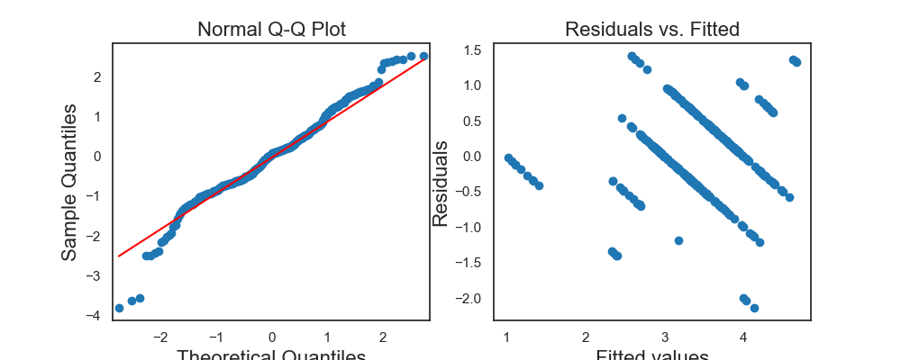

## Evaluation results

### Overall association statistics

The tables in this section show the standard association metrics between *observed* human scores and different types of machine scores. These results are computed on the evaluation set. `raw_trim` scores are truncated to [0.5002, 6.4998000000000005]. `raw_trim_round` scores are computed by first truncating and then rounding the predicted score. Scaled scores are computed by re-scaling the predicted scores using mean and standard deviation of human scores as observed on the training data and mean and standard deviation of machine scores as predicted for the training set.

#### Descriptive holistic score statistics

The table shows distributional properties of human and system scores. SMD values lower then -0.15 or higher than 0.15 are highlighted.

*Please note that for raw scores, SMD values are likely to be affected by possible differences in scale.*

|  | N | h_mean | sys_mean | h_sd | sys_sd | h_min | sys_min | h_max | sys_max | SMD |
| --- | --- | --- | --- | --- | --- | --- | --- | --- | --- | --- |
| raw | 167 | 3.509 | 3.490 | 0.775 | 0.554 | 1.000 | 1.318 | 6.000 | 4.768 | -0.025 |
| raw_trim | 167 | 3.509 | 3.490 | 0.775 | 0.554 | 1.000 | 1.318 | 6.000 | 4.768 | -0.025 |
| raw_trim_round | 167 | 3.509 | 3.413 | 0.775 | 0.583 | 1.000 | 1.000 | 6.000 | 5.000 | -0.124 |
| scale | 167 | 3.509 | 3.531 | 0.775 | 0.752 | 1.000 | 0.584 | 6.000 | 5.265 | 0.028 |
| scale_trim | 167 | 3.509 | 3.531 | 0.775 | 0.752 | 1.000 | 0.584 | 6.000 | 5.265 | 0.028 |
| scale_trim_round | 167 | 3.509 | 3.497 | 0.775 | 0.813 | 1.000 | 1.000 | 6.000 | 5.000 | -0.015 |

#### Association statistics

The table shows the standard association metrics between human scores and machine scores. Note that for computation of `kappa` all machine scores are rounded.

|  | N | corr | wtkappa | R2 | kappa | exact_agr | adj_agr | RMSE |
| --- | --- | --- | --- | --- | --- | --- | --- | --- |
| raw | 167 | 0.611 | 0.578 | 0.362 | 0.380 | 0.000 | 89.222 | 0.617 |
| raw_trim | 167 | 0.611 | 0.578 | 0.362 | 0.380 | 0.000 | 89.222 | 0.617 |
| raw_trim_round | 167 | 0.611 | 0.582 | 0.338 | 0.380 | 64.072 | 98.802 | 0.629 |
| scale | 167 | 0.611 | 0.610 | 0.243 | 0.353 | 0.000 | 87.425 | 0.672 |
| scale_trim | 167 | 0.611 | 0.610 | 0.243 | 0.353 | 0.000 | 87.425 | 0.672 |
| scale_trim_round | 167 | 0.600 | 0.599 | 0.158 | 0.353 | 58.683 | 97.006 | 0.709 |

### Confusion matrix

Confusion matrix using scaled, trimmed, and rounded scores and human scores (rows=system, columns=human).

|  | 1 | 2 | 3 | 4 | 5 | 6 |
| --- | --- | --- | --- | --- | --- | --- |
| 1 | 1 | 0 | 0 | 0 | 0 | 0 |
| 2 | 1 | 2 | 7 | 3 | 0 | 0 |
| 3 | 0 | 5 | 47 | 21 | 0 | 0 |
| 4 | 0 | 2 | 16 | 42 | 2 | 0 |
| 5 | 0 | 0 | 0 | 10 | 6 | 2 |
| 6 | 0 | 0 | 0 | 0 | 0 | 0 |

### Distribution of human and machine scores

The histogram and the table below show the distibution of human scores and scaled, trimmed, and rounded machine scores (as % of all responses). Differences in the table between human and machine distributions larger than 5 percentage points are highlighted.

[figure not shown]

| score | human | sys_scale | difference |
| --- | --- | --- | --- |
| 1.0 | 1.197605 | 0.598802 | -0.599 |
| 2.0 | 5.389222 | 7.784431 | 2.395 |
| 3.0 | 41.916168 | 43.712575 | 1.796 |
| 4.0 | 45.508982 | 37.125749 | -8.383 |
| 5.0 | 4.790419 | 10.778443 | 5.988 |
| 6.0 | 1.197605 | 0.000000 | -1.198 |

True score evaluations

The configuration file did not specify `second_human_score_column` or `rater_error_variance`. At least one of these must be specified to compute evaluations against true scores.

Evaluation by QUESTION

[figure not shown]

Evaluation by L1

[figure not shown]

## Additional fairness analyses

This section presents additional fairness analyses described in detail in [Loukina et al. (2019)](https://aclweb.org/anthology/papers/W/W19/W19-4401/). These analyses consider separately different definitions of fairness and can assist in further trouble-shooting the observed subgroup differences. The evaluations focuses on three dimensions:

- **Outcome fairness** measures:
  - *Overall score accuracy*: whether the automated scores are equally accurate for each group. The metric shows how much of the variance in squared error $(S-H)^2$ is explained by subgroup membership.
  - *Overall score difference*: whether the automated scores are consistently different from human scores for members of a certain group. The metric shows how much of the variance in actual error $S-H$ is explained by subgroup membership.

The differences in the outcome fairness measures might be due to different mean scores (different score distributions) across subgroups or due to differential treatment of different subgroups by the scoring engine or both.

- **Process fairness** measures:
  - *Conditional score difference*: whether the automated scoring model assigns different scores to members from different groups despite them having the same construct proficiency. The metric shows how much additional variance in actual error ($S-H$) is explained by subgroup membership after controlling for human score, which can be thought of as a reasonable proxy for proficiency.

The differences in process fairness measures indicate differential treatment of different subgroups by the scoring model.

Additional fairness evaluation by QUESTION

The summary table shows the overall score accuracy (OSA), overall score difference (OSD) and conditional score difference (CSD). The first row reports the percentage of variance, explained by group membership, the second row shows $p$ value. QUESTION_3 was used as a reference category. Larger values of R2 indicate larger differences between subgroups. Further detail about each model can be found in intermediate output files.

|  | Overall score accuracy | Overall score difference | Conditional score difference |
| --- | --- | --- | --- |
| R2 | -0.015 | -0.017 | -0.011 |
| sig | 0.826 | 0.880 | 0.787 |

The plots show error estimates for different categories for each group (squared error for OSA, raw error for OSD, and conditional raw error for CSD) The estimates have been adjusted for the value of the group used as the Intercept. Black lines show 95% confidence intervals estimated by the model.

[figure not shown]

The plot shows average scale_trim system score for each group conditioned on human score.

[figure not shown]

Additional fairness evaluation by L1

The summary table shows the overall score accuracy (OSA), overall score difference (OSD) and conditional score difference (CSD). The first row reports the percentage of variance, explained by group membership, the second row shows $p$ value. Esperanto was used as a reference category. Larger values of R2 indicate larger differences between subgroups. Further detail about each model can be found in intermediate output files.

|  | Overall score accuracy | Overall score difference | Conditional score difference |
| --- | --- | --- | --- |
| R2 | 0.008 | 0.016 | 0.000 |
| sig | 0.236 | 0.132 | 0.382 |

The plots show error estimates for different categories for each group (squared error for OSA, raw error for OSD, and conditional raw error for CSD) The estimates have been adjusted for the value of the group used as the Intercept. Black lines show 95% confidence intervals estimated by the model.

[figure not shown]

The plot shows average scale_trim system score for each group conditioned on human score.

[figure not shown]

## Principal component analysis

PCA using scaled data and singular value decomposition. This is computed using processed features after the truncation of outliers and other transformations specified in feature config file.

|  | PC1 | PC2 | PC3 | PC4 | PC5 | PC6 | PC7 | PC8 |
| --- | --- | --- | --- | --- | --- | --- | --- | --- |
| FEATURE1 | -0.405 | 0.526 | -0.267 | 0.126 | -0.135 | 0.018 | -0.016 | -0.674 |
| FEATURE2 | -0.414 | -0.105 | 0.024 | -0.043 | 0.629 | -0.304 | -0.570 | 0.030 |
| FEATURE3 | -0.448 | -0.015 | -0.147 | -0.052 | -0.111 | 0.775 | -0.191 | 0.354 |
| FEATURE4 | -0.453 | 0.184 | -0.006 | 0.122 | -0.444 | -0.524 | 0.102 | 0.514 |
| FEATURE5 | -0.431 | -0.205 | 0.095 | -0.187 | 0.373 | 0.024 | 0.765 | -0.065 |
| FEATURE6 | -0.243 | -0.664 | 0.162 | -0.233 | -0.483 | -0.079 | -0.187 | -0.381 |
| FEATURE7 | -0.001 | -0.440 | -0.546 | 0.704 | 0.062 | -0.029 | 0.090 | -0.010 |
| FEATURE8 | 0.116 | -0.037 | -0.757 | -0.617 | -0.010 | -0.155 | 0.015 | 0.084 |

|  | PC1 | PC2 | PC3 | PC4 | PC5 | PC6 | PC7 | PC8 |
| --- | --- | --- | --- | --- | --- | --- | --- | --- |
| Cumulative percentage of variance | 0.318 | 0.466 | 0.596 | 0.710 | 0.806 | 0.888 | 0.958 | 1.000 |
| Eigenvalues | 2.544 | 1.182 | 1.046 | 0.911 | 0.769 | 0.652 | 0.562 | 0.335 |
| Percentage of variance | 0.318 | 0.148 | 0.131 | 0.114 | 0.096 | 0.081 | 0.070 | 0.042 |

[figure not shown]

## Links to intermediate files

Click on the hyperlinks below to see the intermediate experiment files generated as part of this experiment.

**Betas**: csv

**Coefficients**: csv

**Coefficients Scaled**: csv

**Confmatrix**: csv

**Cors Orig**: csv

**Cors Processed**: csv

**Data Composition**: csv

**Data Composition By L1**: csv

**Data Composition By Question**: csv

**Estimates Csd By L1**: csv

**Estimates Csd By Question**: csv

**Estimates Osa By L1**: csv

**Estimates Osa By Question**: csv

**Estimates Osd By L1**: csv

**Estimates Osd By Question**: csv

**Eval**: csv

**Eval By L1**: csv

**Eval By Question**: csv

**Eval Short**: csv

**Fairness Metrics By L1**: csv

**Fairness Metrics By Question**: csv

**Feature**: csv

**Feature Descriptives**: csv

**Feature Descriptivesextra**: csv

**Feature Outliers**: csv

**Margcor Score All Data**: csv

**Margcor Score By L1**: csv

**Margcor Score By Question**: csv

**Model Fit**: csv

**Pca**: csv

**Pcavar**: csv

**Pcor Score All Data**: csv

**Pcor Score By L1**: csv

**Pcor Score By Question**: csv

**Postprocessing Params**: csv

**Pred Processed**: csv

**Pred Train**: csv

**Score Dist**: csv

**Test Excluded Composition**: csv

**Test Features**: csv

**Test Metadata**: csv

**Test Other Columns**: csv

**Test Preprocessed Features**: csv

**Train Excluded Composition**: csv

**Train Features**: csv

**Train Metadata**: csv

**Train Other Columns**: csv

**Train Preprocessed Features**: csv

## System information

This report was generated using rsmtool v9.0.0 on a 64bit computer running Mac OS X.

### Python packages

[output not shown]

[output cut: 93 more lines]

[output not shown]